# Reproducible Projects

2022-12-11

## Reproducible projects with RStudio and R markdown

- The final product of a data analysis project is often a report.
- Many scientific publications can be thought of as a final report of a data analysis.
- The same is true for news articles based on data, an analysis report for your company, or lecture notes for a class on how to analyze data.
- The reports are often on paper or in a PDF that includes a textual description of the findings along with some figures and tables resulting from the analysis.

## Reproducible projects with RStudio and R markdown

- Imagine that after you finish the analysis and the report, you are told that you were given the wrong dataset, you are sent a new one and you are asked to run the same analysis with this new dataset.
- Or what if you realize that a mistake was made and need to re-examine the code, fix the error, and re-run the analysis? Or imagine that someone you are training wants to see the code and be able to reproduce the results to learn about your approach?
- Situations like the ones just described are actually quite common for a data scientist.

## Reproducible projects with RStudio and R markdown

- Here, we describe how you can keep your data science projects organized with RStudio so that re-running an analysis is straight-forward.
- We then demonstrate how to generate reproducible reports with R markdown and the **knitR** package in a way that will greatly help with recreating reports with minimal work.
- This is possible due to the fact that R markdown documents permit code and textual descriptions to be combined into the same document, and the figures and tables produced by the code are automatically added to the document.

## Reproducible projects with RStudio and R markdown

## RStudio projects

- RStudio provides a way to keep all the components of a data analysis project organized into one folder and to keep track of information about this project, such as the Git status of files, in one file.
- We demonstrate how RStudio facilitates the use of Git and GitHub through RStudio projects.
- In this section we quickly demonstrate how to start a new a project and some recommendations on how to keep these organized.
- RStudio projects also permit you to have several RStudio sessions open and keep track of which is which.

## RStudio projects

- To start a project, click on *File* and then *New Project*.
- Often we have already created a folder to save the work, as we did in Section @ref(prep-project) and we select *Existing Directory*.
- Here we show an example.
- in which we have not yet created a folder and select the *New Directory* option.

## RStudio projects

[figure not shown]

[figure not shown]

## RStudio projects

- Then, for a data analysis project, you usually select the *New Project* option:

## RStudio projects

[figure not shown]

## RStudio projects

- Now you will have to decide on the location of the folder that will be associated with your project, as well as the name of the folder.
- When choosing a folder name, just like with file names, make sure it is a meaningful name that will help you remember what the project is about.
- As with files, we recommend using lower case letters, no spaces, and hyphens to separate words.
- We will call the folder for this project *my-first-project*.

## RStudio projects

- This will then generate a *Rproj* file called *my-first-project.Rproj* in the folder associated with the project.
- We will see how this is useful a few lines below.

## RStudio projects

[figure not shown]

## RStudio projects

- You will be given options on where this folder should be on your filesystem.
- In this example, we will place it in our home folder, but this is generally not good practice.
- As we described in Section @ref(prep-project) in the Unix chapter, you want to organize your filesystem following a hierarchical approach and with a folder called *projects* where you keep a folder for each project.

## RStudio projects

[figure not shown]

## RStudio projects

- When you start using RStudio with a project, you will see the project name in the upper right corner.
- This will remind you what project this particular RStudio session belongs to.
- When you open an RStudio session with no project, it will say *Project: (None)*.
- When working on a project, all files will be saved and searched for in the folder associated with the project.
- Below, we show an example of a script that we wrote and saved with the name *code.R*.

## RStudio projects

- Because we used a meaningful name for the project, we can be a bit less informative when we name the files.
- Although we do not do it here, you can have several scripts open at once.
- You simply need to click *File*, then *New File* and pick the type of file you want to edit.

## RStudio projects

[figure not shown]

## RStudio projects

- One of the main advantages of using Projects is that after closing RStudio, if we wish to continue where we left off on the project, we simply double click or open the file saved when we first created the RStudio project.
- In this case, the file is called *my-first-project.Rproj*.
- If we open this file, RStudio will start up and open the scripts we were editing.

## RStudio projects

[figure not shown]

[figure not shown]

## RStudio projects

- Another advantage is that if you click on two or more different Rproj files, you start new RStudio and R sessions for each.

## R markdown

- R markdown is a format for *literate programming* documents.
- It is based on *markdown*, a markup language that is widely used to generate html pages.
- You can learn more about markdown here: https://www.markdowntutorial.com/.
- Literate programming weaves instructions, documentation, and detailed comments in between machine executable code, producing a document that describes the program that is best for human understanding (Knuth 1984).

## R markdown

- Unlike a word processor, such as Microsoft Word, where what you see is what you get, with R markdown, you need to *compile* the document into the final report.
- The R markdown document looks different than the final product.
- This seems like a disadvantage at first, but it is not because, for example, instead of producing plots and inserting them one by one into the word processing document, the plots are automatically added.
- In RStudio, you can start an R markdown document by clicking on *File*, *New File*, the *R Markdown*.

## R markdown

- You will then be asked to enter a title and author for your document.
- We are going to prepare a report on gun murders so we will give it an appropriate name.
- You can also decide what format you would like the final report to be in: HTML, PDF, or Microsoft Word.
- Later, we can easily change this, but here we select html as it is the preferred format for debugging purposes:

## R markdown

[figure not shown]

[figure not shown]

## R markdown

- This will generate a template file:

[figure not shown]

## R markdown

- As a convention, we use the `Rmd` suffix for these files.
- Once you gain experience with R Markdown, you will be able to do this without the template and can simply start from a blank template.
- In the template, you will see several things to note.

## The header

- At the top you see:

```
---
title: "Report on Gun Murders"
author: "Rafael Irizarry"
date: "April 16, 2018"
output: html_document
---
```

- The things between the `---` is the header.
- We actually don’t need a header, but it is often useful.
- You can define many other things in the header than what is included in the template.

## The header

- We don’t discuss those here, but much information is available online.
- The one parameter that we will highlight is `output`.
- By changing this to, say, `pdf_document`, we can control the type of output that is produced when we compile.

## R code chunks

- In various places in the document, we see something like this:
- summary(pressure).
- These are the code chunks.
- When you compile the document, the R code inside the chunk, in this case `summary(pressure)`, will be evaluated and the result included in that position in the final document.
- To add your own R chunks, you can type the characters above quickly with the key binding command-option-I on the Mac and Ctrl-Alt-I on Windows.

## R code chunks

- This applies to plots as well; the plot will be placed in that position.
- We can write something like this:
- plot(pressure).
- By default, the code will show up as well.
- To avoid having the code show up, you can use an argument.
- To avoid this, you can use the argument `echo=FALSE`.
- For example:

## R code chunks

- summary(pressure).
- We recommend getting into the habit of adding a label to the R code chunks.
- This will be very useful when debugging, among other situations.
- You do this by adding a descriptive word like this:
- summary(pressure).

## Global options

- One of the R chunks contains a complex looking call:
- knitr::opts_chunk$set(echo = TRUE).
- We will not cover this here, but as you become more experienced with R Markdown, you will learn the advantages of setting global options for the compilation process.

## knitR

- We use the **knitR** package to compile R markdown documents.
- The specific function used to compile is the `knit` function, which takes a filename as input.
- RStudio provides a button that makes it easier to compile the document.
- For the screenshot below, we have edited the document so that a report on gun murders is produced.
- You can see the file here: https://raw.githubusercontent.com/rairizarry/murders/master/report.Rmd.

## knitR

- You can now click on the `Knit` button:

[figure not shown]

## knitR

- The first time you click on the *Knit* button, a dialog box may appear asking you to install packages you need.

## knitR

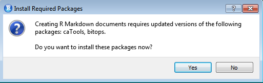

## knitR

- Once you have installed the packages, clicking the *Knit* will compile your R markdown file and the resulting document will pop up:
- This produces an html document which you can see in your working directory.
- To view it, open a terminal and list the files.
- You can open the file in a browser and use this to present your analysis.

## knitR

- You can also produce a PDF or Microsoft document by changing:
- `output: html_document` to `output: pdf_document` or `output: word_document`.
- We can also produce documents that render on GitHub using `output: github_document`.

## knitR

[figure not shown]

## knitR

- This will produce a markdown file, with suffix `md`, that renders in GitHub.
- Because we have uploaded these files to GitHub, you can click on the `md` file and you will see the report as a webpage:

## knitR

[figure not shown]

## knitR

[figure not shown]

## knitR

- This is a convenient way to share your reports.

## More on R markdown

- There is a lot more you can do with R markdown.
- We highly recommend you continue learning as you gain more experience writing reports in R.
- There are many free resources on the internet including:
- - RStudio’s tutorial: https://rmarkdown.rstudio.com.
- - The cheat sheet: https://www.rstudio.com/wp-content/uploads/2015/02/rmarkdown-cheatsheet.pdf.

## More on R markdown

- - The knitR book: https://yihui.name/knitr/.

## Organizing a data science project

- In this section we put it all together to create the US murders project and share it on GitHub.

## Create directories in Unix

- In Section @ref(prep-project) we demonstrated how to use Unix to prepare for a data science project using an example.
- Here we continue this example and show how to use RStudio.
- In Section @ref(prep-project) we created the following directories using Unix:

```bash
cd ~
cd projects
mkdir murders
cd murders
mkdir data rdas
```

## Create an RStudio project

- In the next section we will use create an RStudio project.
- In RStudio we go to *File* and then *New Project…* and when given the options we pick *Existing Directory*.
- We then write the full path of the `murders` directory created above.

## Create an RStudio project

[figure not shown]

[figure not shown]

## Create an RStudio project

- Once you do this, you will see the `rdas` and `data` directories you created in the RStudio *Files* tab.

## Create an RStudio project

[figure not shown]

## Create an RStudio project

- Keep in mind that when we are in this project, our default working directory will be `~/projects/murders`.
- You can confirm this by typing `getwd()` into your R session.
- This is important because it will help us organize the code when we need to write file paths.

## Create an RStudio project

- **Pro tip: always use relative paths in code for data science projects. These should be relative to the default working directory.**
- The problem with using full paths is that your code is unlikely to work on filesystems other than yours since the directory structures will be different.
- This includes using the home directory `~` as part of your path.

## Edit some R scripts

- Let’s now write a script that downloads a file into the data directory.
- We will call this file `download-data.R`.
- The content of this file will be:

```r
url <- "https://raw.githubusercontent.com/rafalab/dslabs/master/inst/
extdata/murders.csv"
dest_file <- "data/murders.csv"
download.file(url, destfile = dest_file)
```

- Notice that we are using the relative path `data/murders.csv`.

## Edit some R scripts

- Run this code in R and you will see that a file is added to the `data` directory.
- Now we are ready to write a script to read this data and prepare a table that we can use for analysis.
- Call the file `wrangle-data.R`.
- The content of this file will be:

## Edit some R scripts

```r
library(tidyverse)
murders <- read_csv("data/murders.csv")
murders <-murders |> mutate(region = factor(region),
                             rate = total / population * 10^5)
save(murders, file = "rdas/murders.rda")
```

- Again note that we use relative paths exclusively.
- In this file, we introduce an R command we have not seen: `save`.
- The `save` command in R saves objects into what is called an *rda file*: *rda* is short for R data.

## Edit some R scripts

- But we still want to be able to generate the entire analysis from the raw data.
- Now we are ready to write the analysis file.
- Let’s call it `analysis.R`.
- The content should be the following:

## Edit some R scripts

```r
library(tidyverse)
load("rdas/murders.rda")
murders |> mutate(abb = reorder(abb, rate)) |>
  ggplot(aes(abb, rate)) +
  geom_bar(width = 0.5, stat = "identity", color = "black") +
  coord_flip()
```

## Edit some R scripts

- If you run this analysis, you will see that it generates a plot.

## Create some more directories using Unix

- Now suppose we want to save the generated plot for use in a report or presentation.
- We can do this with the **ggplot** command `ggsave`.
- But where do we put the graph? We should be systematically organized so we will save plots to a directory called `figs`.
- Start by creating a directory by typing the following in the terminal:

```bash
mkdir figs
```

- and then you can add the line:

## Create some more directories using Unix

```r
ggsave("figs/barplot.png")
```

## Create some more directories using Unix

- to your R script.
- If you run the script now, a png file will be saved into the `figs` directory.
- If we wanted to copy that file to some other directory where we are developing a presentation, we can avoid using the mouse by using the `cp` command in our terminal.

## Add a README file

- You now have a self-contained analysis in one directory.
- One final recommendation is to create a `README.txt` file describing what each of these files does for the benefit of others reading your code, including your future self.
- This would not be a script but just some notes.
- One of the options provided when opening a new file in RStudio is a text file.
- You can save something like this into the text file:

```
We analyze US gun murder data collected by the FBI.
download-data.R - Downloads csv file to data directory
wrangle-data.R - Creates a derived dataset and saves as R object in rdas
directory
analysis.R - A plot is generated and saved in the figs directory.
```

## Add a README file

[output not shown]

## Add a README file

## Initializing a Git directory

- In Section @ref(init) we demonstrated how to initialize a Git directory and connect it to the upstream repository on GitHub, which we already created in that section.
- We can do this in the Unix terminal:

```bash
cd ~/projects/murders
git init
git add README.txt
git commit -m "First commit. Adding README.txt file just to get started"
git remote add origin `https://github.com/rairizarry/murders.git`
git push
```

## Add, commit, and push files using RStudio

- We can continue adding and committing each file, but it might be easier to use RStudio.
- To do this, start the project by opening the Rproj file.
- The git icons should appear and you can add, commit and push using these.

## Add, commit, and push files using RStudio

[figure not shown]

[figure not shown]

[figure not shown]

## Add, commit, and push files using RStudio

- We can now go to GitHub and confirm that our files are there.

## Add, commit, and push files using RStudio

[figure not shown]

## Add, commit, and push files using RStudio

- You can see a version of this project, organized with Unix directories, on GitHub<sup>1</sup>.
- You can download a copy to your computer by using the `git clone` command on your terminal.
- This command will create a directory called `murders` in your working directory, so be careful where you call it from.

```r
git clone https://github.com/rairizarry/murders.git
```